# Validation of ICD-9-CM/ICD-10-CM Codes for Automated Electronic Scoring of APACHE II, APACHE III, and SAPS II

Analysis for ASHP Poster

Eric Kao, Brian Gulbis

November 30, 2016

## Patient Selection

- Patients meeting inclusion criteria: 16242
- Reasons for exclusion:
  - Pregnant: 203
  - Prisoner: 77
  - ICU stay < 12 hours: 1077
  - Diagnosis coding contained both ICD-9-CM and ICD-10-CM: 548
  - Missing data needed to calculate risk scores: 9165
  - Re-encounters (only included each patient once) : 1782
- Total number of eligible patients remaining to sample from: 3390

## Patient Demographics

```r
deceased <- "Deceased/Hospice"
home <- "Home"
transfer <- "Transferred"
dispos <- list("Deceased" = deceased,
               "Expired/Donor" = deceased,
               "Hospice-Home" = deceased,
               "Hospice-Medical Facility" = deceased,
               "Home Care with Home Health" = home,
               "Home or Self Care" = home,
               "Left Against Medical Advise" = home,
               "Skilled Nursing Facility" = transfer,
               "DC/DISC TO REHAB" = transfer,
               "Long Term Care" = transfer,
               "Intermediate Care" = transfer,
               "Acute Care" = transfer,
               "Federal Healthcare Facility" = transfer,
               "DC/TF To Psych Hosp" = transfer)
df <- data_demographics %>%
    dmap_at("disposition", str_replace_all, pattern = dispos) %>%
    dmap_at("race", factor) %>%
    dmap_at("race", fct_lump, n = 4) %>%
    select(-pie.id, Age = age, Sex = sex, Race = race, Disposition = disposition, `Hospital Length of Stay (days)` = length.stay, `ICU Location` = location)
vars <- names(df)
tbl <- CreateTableOne(vars, data = df)
ptbl <- print(tbl, printToggle = FALSE)
rownames(ptbl) <- str_replace_all(rownames(ptbl), "   ", "- ")
knitr::kable(ptbl, caption = "Demographics")
```

|  | Overall |
| --- | --- |
| n | 200 |
| Age (mean (sd)) | 60.68 (16.54) |
| Sex = Male (%) | 123 (61.5) |
| Race (%) |  |
| - African American | 49 (28.0) |
| - Asian | 8 ( 4.6) |
| - White/Caucasian | 73 (41.7) |
| - Other | 45 (25.7) |
| Disposition (%) |  |
| - Deceased/Hospice | 37 (18.5) |
| - Home | 109 (54.5) |
| - Transferred | 54 (27.0) |
| Hospital Length of Stay (days) (mean (sd)) | 12.07 (12.04) |
| ICU Location (%) |  |
| - Cullen 2 E Medical Intensive Care Unit | 60 (30.0) |
| - Hermann 3 Shock Trauma Intensive Care Unit | 14 ( 7.0) |
| - Hermann 3 Transplant Surgical ICU | 19 ( 9.5) |
| - HVI Cardiac Care Unit | 20 (10.0) |
| - HVI Cardiovascular Intensive Care Unit | 34 (17.0) |
| - Jones 7 J Elective Neuro ICU | 53 (26.5) |

## Primary endpoint

### APACHE II

- Mean and median score for each comorbidity set

```r
scores <- ls(pattern = "score_apache2")
all_scores <- map(scores, ~mutate(get(.x), score = .x)) %>%
    map(~select(.x, pie.id, score, apache2)) %>%
    map_df(~semi_join(.x, manual_patients, by = "pie.id")) %>%
    arrange(pie.id, score) %>%
    dmap_at("score", str_replace_all, pattern = "score_apache2_", replacement = "")
man <- filter(all_scores, score == "manual")$apache2
result <- all_scores %>%
    select(-pie.id) %>%
    group_by(score) %>%
    summarize_all(funs(mean, sd, median, IQR_low = quantile(., 0.25), IQR_high = quantile(., 0.75)))
knitr::kable(result)
```

| score | mean | sd | median | IQR_low | IQR_high |
| --- | --- | --- | --- | --- | --- |
| ahrq | 20.20 | 6.858220 | 20 | 15 | 24.00 |
| ahrq_drg | 19.79 | 6.832225 | 19 | 15 | 24.00 |
| ek | 20.05 | 6.909865 | 20 | 15 | 24.00 |
| ek_drg | 19.65 | 6.866824 | 19 | 15 | 24.00 |
| elixhauser | 20.18 | 6.927304 | 20 | 15 | 24.00 |
| elixhauser_drg | 19.77 | 6.900375 | 19 | 15 | 24.00 |
| manual | 19.87 | 7.020651 | 19 | 15 | 24.25 |
| quan | 20.18 | 6.927304 | 20 | 15 | 24.00 |
| quan_drg | 19.78 | 6.891959 | 19 | 15 | 24.00 |

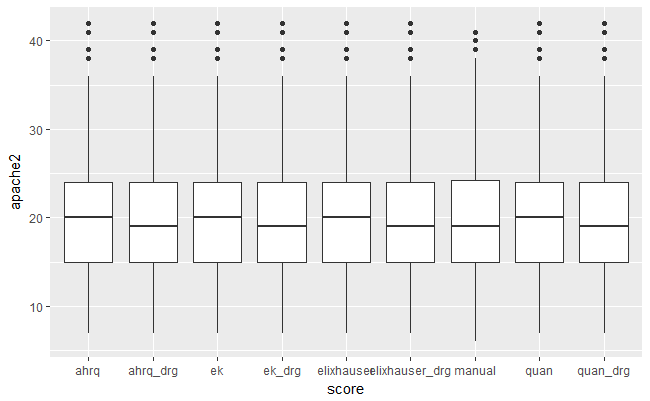

```r
ggplot(all_scores, aes(x = score, y = apache2)) +
    geom_boxplot()
```

```r
    # geom_jitter(color = "light blue", alpha = 0.6)
```

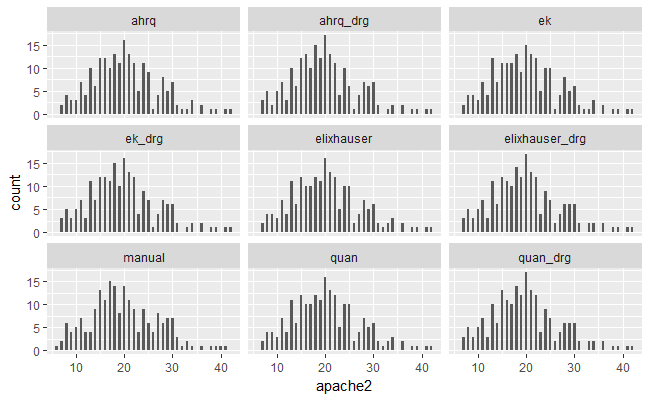

```r
ggplot(all_scores, aes(x = apache2)) +
    geom_histogram(binwidth = 0.5) +
    facet_wrap(~ score)
```

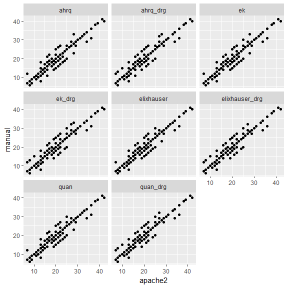

```r
df <- all_scores %>%
    spread(score, apache2) %>%
    gather(score, apache2, -pie.id, -manual)
# ggplot(df, aes(x = apache2, y = manual)) +
#     geom_jitter(aes(color = score), alpha = 0.6)
ggplot(df, aes(x = apache2, y = manual)) +
    geom_point() +
    # geom_smooth() +
    facet_wrap(~ score)
```

- Comparison of scores
  - Results run using both the t-test and Wilcoxon signed rank test (assumes non-parametric data, is more difficult to achieve significance)
  - To account for performing multiple comparisons, a BH (Benjamini and Hochberg) correction is applied to the p-values; **use the bh.adjust value as the p-value**
    - Reference: http://ies.ed.gov/ncee/pubs/20084018/app_b.asp

```r
t <- all_scores[, -1] %>%
    filter(score != "manual") %>%
    group_by(score) %>%
    do(tidy(t.test(.$apache2, man, paired = TRUE))) %>%
    ungroup() %>%
    mutate(bh.adjust = p.adjust(p.value, "BH")) %>%
    select(score:p.value, bh.adjust, everything())
knitr::kable(t, digits = 4)
```

| score | estimate | statistic | p.value | bh.adjust | parameter | conf.low | conf.high | method | alternative |
| --- | --- | --- | --- | --- | --- | --- | --- | --- | --- |
| ahrq | 0.33 | 2.0591 | 0.0408 | 0.1306 | 199 | 0.0140 | 0.6460 | Paired t-test | two.sided |
| ahrq_drg | -0.08 | -0.4981 | 0.6190 | 0.6190 | 199 | -0.3967 | 0.2367 | Paired t-test | two.sided |
| ek | 0.18 | 1.1170 | 0.2653 | 0.4245 | 199 | -0.1378 | 0.4978 | Paired t-test | two.sided |
| ek_drg | -0.22 | -1.3754 | 0.1706 | 0.3411 | 199 | -0.5354 | 0.0954 | Paired t-test | two.sided |
| elixhauser | 0.31 | 1.9808 | 0.0490 | 0.1306 | 199 | 0.0014 | 0.6186 | Paired t-test | two.sided |
| elixhauser_drg | -0.10 | -0.6386 | 0.5238 | 0.6190 | 199 | -0.4088 | 0.2088 | Paired t-test | two.sided |
| quan | 0.31 | 1.9808 | 0.0490 | 0.1306 | 199 | 0.0014 | 0.6186 | Paired t-test | two.sided |
| quan_drg | -0.09 | -0.5734 | 0.5670 | 0.6190 | 199 | -0.3995 | 0.2195 | Paired t-test | two.sided |

```r
mw <- all_scores[, -1] %>%
    filter(score != "manual") %>%
    group_by(score) %>%
    do(tidy(wilcox.test(.$apache2, man, paired = TRUE, conf.int = TRUE, exact = FALSE))) %>%
    ungroup() %>%
    mutate(bh.adjust = p.adjust(p.value, "BH")) %>%
    select(score:p.value, bh.adjust, everything())
knitr::kable(mw, digits = 4)
```

| score | estimate | statistic | p.value | bh.adjust | conf.low | conf.high | method | alternative |
| --- | --- | --- | --- | --- | --- | --- | --- | --- |
| ahrq | 1.5 | 1644.0 | 0.0563 | 0.1676 | -0.0001 | 2.0000 | Wilcoxon signed rank test with continuity correction | two.sided |
| ahrq_drg | 0.0 | 1070.0 | 0.5179 | 0.5179 | -1.5000 | 0.0000 | Wilcoxon signed rank test with continuity correction | two.sided |
| ek | 0.0 | 1448.5 | 0.3147 | 0.5036 | -0.0001 | 2.0000 | Wilcoxon signed rank test with continuity correction | two.sided |
| ek_drg | 0.0 | 936.0 | 0.1357 | 0.2715 | -1.5000 | 0.0000 | Wilcoxon signed rank test with continuity correction | two.sided |
| elixhauser | 1.5 | 1551.0 | 0.0628 | 0.1676 | -0.0001 | 1.9999 | Wilcoxon signed rank test with continuity correction | two.sided |
| elixhauser_drg | 0.0 | 990.0 | 0.4483 | 0.5179 | -1.5000 | 0.0001 | Wilcoxon signed rank test with continuity correction | two.sided |
| quan | 1.5 | 1551.0 | 0.0628 | 0.1676 | -0.0001 | 1.9999 | Wilcoxon signed rank test with continuity correction | two.sided |
| quan_drg | 0.0 | 1030.5 | 0.4863 | 0.5179 | -1.5000 | 0.0000 | Wilcoxon signed rank test with continuity correction | two.sided |

```r
options(scipen = 999)
mw_pair <- all_scores %>%
    dmap_at("score", factor) %>%
    dmap_at("score", ~fct_relevel(.x, c("manual", "ek", "ek_drg"))) %>%
    do(tidy(pairwise.wilcox.test(.$apache2, .$score, p.adj = "BH", paired = TRUE, exact = FALSE)))
```

#### Linear Regression Model

```r
lm <- df %>%
    group_by(score) %>%
    do(fit = lm(manual ~ apache2, data = .))
knitr::kable(glance(lm, fit), digits = 4)
```

| score | r.squared | adj.r.squared | sigma | statistic | p.value | df | logLik | AIC | BIC | deviance | df.residual |
| --- | --- | --- | --- | --- | --- | --- | --- | --- | --- | --- | --- |
| ahrq | 0.8967 | 0.8962 | 2.2624 | 1718.366 | 0 | 2 | -446.0658 | 898.1315 | 908.0265 | 1013.4322 | 198 |
| ahrq_drg | 0.8960 | 0.8955 | 2.2695 | 1706.410 | 0 | 2 | -446.6916 | 899.3832 | 909.2782 | 1019.7944 | 198 |
| ek | 0.8960 | 0.8955 | 2.2693 | 1706.705 | 0 | 2 | -446.6761 | 899.3522 | 909.2472 | 1019.6365 | 198 |
| ek_drg | 0.8971 | 0.8966 | 2.2574 | 1726.889 | 0 | 2 | -445.6220 | 897.2440 | 907.1390 | 1008.9449 | 198 |
| elixhauser | 0.9020 | 0.9015 | 2.2035 | 1822.143 | 0 | 2 | -440.7920 | 887.5840 | 897.4790 | 961.3710 | 198 |
| elixhauser_drg | 0.9016 | 0.9011 | 2.2078 | 1814.341 | 0 | 2 | -441.1790 | 888.3579 | 898.2529 | 965.0983 | 198 |
| quan | 0.9020 | 0.9015 | 2.2035 | 1822.143 | 0 | 2 | -440.7920 | 887.5840 | 897.4790 | 961.3710 | 198 |
| quan_drg | 0.9011 | 0.9006 | 2.2135 | 1804.009 | 0 | 2 | -441.6937 | 889.3874 | 899.2824 | 970.0789 | 198 |

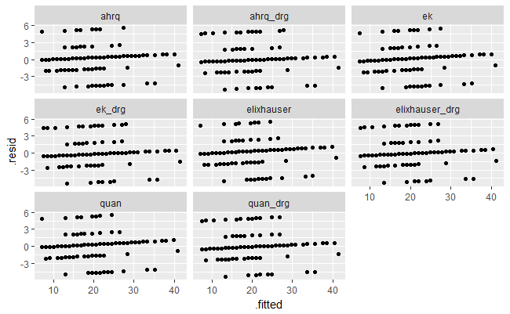

```r
augment(lm, fit) %>%
    ggplot(aes(x = .fitted, y = .resid)) +
    geom_point() +
    # geom_smooth(se = FALSE) +
    facet_wrap(~ score)
```

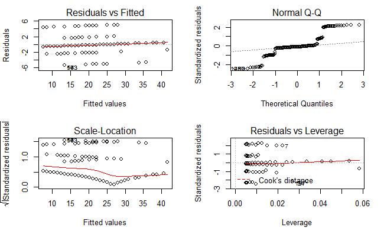

```r
mod_df <- df %>%
    filter(score == "ek_drg")
mod <- lm(manual ~ apache2, data = mod_df)
par(mfrow = c(2, 2))
plot(mod)
```

- Compare differences in score from comorbidity sets vs. manual
  - Column *num_diff* indicates the number of patients with a score that differed from manual
  - Mean and median indicate the difference from the manual score
    - These were only calculated for those patients whose score was different from manual
    - If all patients were included, the number is skewed towards 0 by all the patients with the same scores

```r
diff <- all_scores %>%
    spread(score, apache2) %>%
    mutate_at(vars(-pie.id, -manual), funs(abs(. - manual))) %>%
    gather(score, apache2, -pie.id, -manual) %>%
    select(-pie.id, -manual) %>%
    filter(apache2 > 0) %>%
    group_by(score) %>%
    summarize_all(funs(num_diff = length, mean, sd, median, IQR_low = quantile(., 0.25), IQR_high = quantile(., 0.75)))
knitr::kable(diff, caption = "Differences in APACHE II Scores")
```

| score | num_diff | mean | sd | median | IQR_low | IQR_high |
| --- | --- | --- | --- | --- | --- | --- |
| ahrq | 72 | 3.500000 | 1.510526 | 3.5 | 2 | 5 |
| ahrq_drg | 68 | 3.588235 | 1.508536 | 5.0 | 2 | 5 |
| ek | 71 | 3.521127 | 1.510526 | 5.0 | 2 | 5 |
| ek_drg | 68 | 3.588235 | 1.508536 | 5.0 | 2 | 5 |
| elixhauser | 70 | 3.457143 | 1.510214 | 2.0 | 2 | 5 |
| elixhauser_drg | 66 | 3.545454 | 1.510800 | 5.0 | 2 | 5 |
| quan | 70 | 3.457143 | 1.510214 | 2.0 | 2 | 5 |
| quan_drg | 67 | 3.522388 | 1.511153 | 5.0 | 2 | 5 |

### APACHE III

```r
scores <- ls(pattern = "score_apache3")
all_scores <- map(scores, ~mutate(get(.x), score = .x)) %>%
    map(~select(.x, pie.id, score, apache3)) %>%
    map_df(~semi_join(.x, manual_patients, by = "pie.id")) %>%
    arrange(pie.id, score) %>%
    dmap_at("score", str_replace_all, pattern = "score_apache3_", replacement = "")
man <- filter(all_scores, score == "manual")$apache3
result <- all_scores %>%
    select(-pie.id) %>%
    group_by(score) %>%
    summarize_all(funs(mean, sd, median, IQR_low = quantile(., 0.25), IQR_high = quantile(., 0.75)))
knitr::kable(result)
```

| score | mean | sd | median | IQR_low | IQR_high |
| --- | --- | --- | --- | --- | --- |
| ahrq | 85.715 | 29.29976 | 82.0 | 65.75 | 103.25 |
| ahrq_drg | 85.555 | 29.25932 | 82.0 | 65.00 | 103.25 |
| ek | 85.715 | 29.29976 | 82.0 | 65.75 | 103.25 |
| ek_drg | 85.555 | 29.25932 | 82.0 | 65.00 | 103.25 |
| elixhauser | 85.715 | 29.29976 | 82.0 | 65.75 | 103.25 |
| elixhauser_drg | 85.555 | 29.25932 | 82.0 | 65.00 | 103.25 |
| manual | 84.805 | 28.99847 | 81.5 | 63.75 | 103.00 |
| quan | 85.715 | 29.29976 | 82.0 | 65.75 | 103.25 |
| quan_drg | 85.555 | 29.25932 | 82.0 | 65.00 | 103.25 |

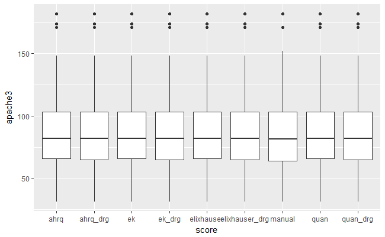

```r
ggplot(all_scores, aes(x = score, y = apache3)) +
    geom_boxplot()
```

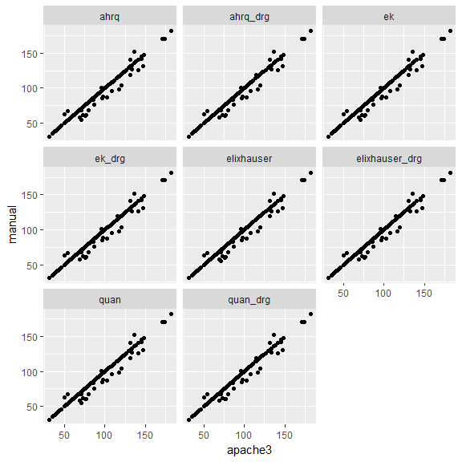

```r
df <- all_scores %>%
    spread(score, apache3) %>%
    gather(score, apache3, -pie.id, -manual)
ggplot(df, aes(x = apache3, y = manual)) +
    geom_point() +
    # geom_smooth() +
    facet_wrap(~ score)
```

- Comparison of scores

```r
t <- all_scores[, -1] %>%
    filter(score != "manual") %>%
    group_by(score) %>%
    do(tidy(t.test(.$apache3, man, paired = TRUE))) %>%
    ungroup() %>%
    mutate(bh.adjust = p.adjust(p.value, "BH")) %>%
    select(score:p.value, bh.adjust, everything())
knitr::kable(t, digits = 4)
```

| score | estimate | statistic | p.value | bh.adjust | parameter | conf.low | conf.high | method | alternative |
| --- | --- | --- | --- | --- | --- | --- | --- | --- | --- |
| ahrq | 0.91 | 2.9503 | 0.0036 | 0.0071 | 199 | 0.3018 | 1.5182 | Paired t-test | two.sided |
| ahrq_drg | 0.75 | 2.5453 | 0.0117 | 0.0117 | 199 | 0.1690 | 1.3310 | Paired t-test | two.sided |
| ek | 0.91 | 2.9503 | 0.0036 | 0.0071 | 199 | 0.3018 | 1.5182 | Paired t-test | two.sided |
| ek_drg | 0.75 | 2.5453 | 0.0117 | 0.0117 | 199 | 0.1690 | 1.3310 | Paired t-test | two.sided |
| elixhauser | 0.91 | 2.9503 | 0.0036 | 0.0071 | 199 | 0.3018 | 1.5182 | Paired t-test | two.sided |
| elixhauser_drg | 0.75 | 2.5453 | 0.0117 | 0.0117 | 199 | 0.1690 | 1.3310 | Paired t-test | two.sided |
| quan | 0.91 | 2.9503 | 0.0036 | 0.0071 | 199 | 0.3018 | 1.5182 | Paired t-test | two.sided |
| quan_drg | 0.75 | 2.5453 | 0.0117 | 0.0117 | 199 | 0.1690 | 1.3310 | Paired t-test | two.sided |

```r
mw <- all_scores[, -1] %>%
    filter(score != "manual") %>%
    group_by(score) %>%
    do(tidy(wilcox.test(.$apache3, man, paired = TRUE, conf.int = TRUE, exact = FALSE))) %>%
    ungroup() %>%
    mutate(bh.adjust = p.adjust(p.value, "BH")) %>%
    select(score:p.value, bh.adjust, everything())
knitr::kable(mw, digits = 4)
```

| score | estimate | statistic | p.value | bh.adjust | conf.low | conf.high | method | alternative |
| --- | --- | --- | --- | --- | --- | --- | --- | --- |
| ahrq | 9.0000 | 283.5 | 0.0062 | 0.0123 | 2.9999 | 13.0 | Wilcoxon signed rank test with continuity correction | two.sided |
| ahrq_drg | 7.0001 | 251.0 | 0.0176 | 0.0176 | 1.5000 | 11.5 | Wilcoxon signed rank test with continuity correction | two.sided |
| ek | 9.0000 | 283.5 | 0.0062 | 0.0123 | 2.9999 | 13.0 | Wilcoxon signed rank test with continuity correction | two.sided |
| ek_drg | 7.0001 | 251.0 | 0.0176 | 0.0176 | 1.5000 | 11.5 | Wilcoxon signed rank test with continuity correction | two.sided |
| elixhauser | 9.0000 | 283.5 | 0.0062 | 0.0123 | 2.9999 | 13.0 | Wilcoxon signed rank test with continuity correction | two.sided |
| elixhauser_drg | 7.0001 | 251.0 | 0.0176 | 0.0176 | 1.5000 | 11.5 | Wilcoxon signed rank test with continuity correction | two.sided |
| quan | 9.0000 | 283.5 | 0.0062 | 0.0123 | 2.9999 | 13.0 | Wilcoxon signed rank test with continuity correction | two.sided |
| quan_drg | 7.0001 | 251.0 | 0.0176 | 0.0176 | 1.5000 | 11.5 | Wilcoxon signed rank test with continuity correction | two.sided |

#### Linear Regression Model

```r
lm <- df %>%
    group_by(score) %>%
    do(fit = lm(manual ~ apache3, data = .))
knitr::kable(glance(lm, fit), digits = 4)
```

| score | r.squared | adj.r.squared | sigma | statistic | p.value | df | logLik | AIC | BIC | deviance | df.residual |
| --- | --- | --- | --- | --- | --- | --- | --- | --- | --- | --- | --- |
| ahrq | 0.9778 | 0.9777 | 4.3280 | 8735.812 | 0 | 2 | -575.8020 | 1157.604 | 1167.499 | 3708.786 | 198 |
| ahrq_drg | 0.9797 | 0.9796 | 4.1402 | 9564.716 | 0 | 2 | -566.9292 | 1139.858 | 1149.753 | 3393.891 | 198 |
| ek | 0.9778 | 0.9777 | 4.3280 | 8735.812 | 0 | 2 | -575.8020 | 1157.604 | 1167.499 | 3708.786 | 198 |
| ek_drg | 0.9797 | 0.9796 | 4.1402 | 9564.716 | 0 | 2 | -566.9292 | 1139.858 | 1149.753 | 3393.891 | 198 |
| elixhauser | 0.9778 | 0.9777 | 4.3280 | 8735.812 | 0 | 2 | -575.8020 | 1157.604 | 1167.499 | 3708.786 | 198 |
| elixhauser_drg | 0.9797 | 0.9796 | 4.1402 | 9564.716 | 0 | 2 | -566.9292 | 1139.858 | 1149.753 | 3393.891 | 198 |
| quan | 0.9778 | 0.9777 | 4.3280 | 8735.812 | 0 | 2 | -575.8020 | 1157.604 | 1167.499 | 3708.786 | 198 |
| quan_drg | 0.9797 | 0.9796 | 4.1402 | 9564.716 | 0 | 2 | -566.9292 | 1139.858 | 1149.753 | 3393.891 | 198 |

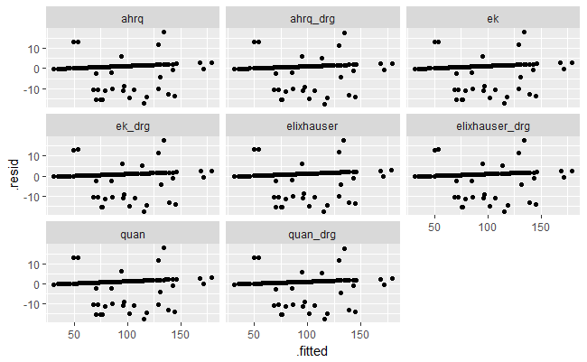

```r
augment(lm, fit) %>%
    ggplot(aes(x = .fitted, y = .resid)) +
    geom_point() +
    facet_wrap(~ score)
```

- Differences in score

```r
diff <- all_scores %>%
    spread(score, apache3) %>%
    mutate_at(vars(-pie.id, -manual), funs(abs(. - manual))) %>%
    gather(score, apache3, -pie.id, -manual) %>%
    select(-pie.id, -manual) %>%
    filter(apache3 > 0) %>%
    group_by(score) %>%
    summarize_all(funs(num_diff = length, mean, sd, median, IQR_low = quantile(., 0.25), IQR_high = quantile(., 0.75)))
knitr::kable(diff, caption = "Difference in APACHE III Scores")
```

| score | num_diff | mean | sd | median | IQR_low | IQR_high |
| --- | --- | --- | --- | --- | --- | --- |
| ahrq | 26 | 11.38462 | 4.825573 | 12 | 10 | 16 |
| ahrq_drg | 25 | 10.88000 | 5.035871 | 12 | 6 | 16 |
| ek | 26 | 11.38462 | 4.825573 | 12 | 10 | 16 |
| ek_drg | 25 | 10.88000 | 5.035871 | 12 | 6 | 16 |
| elixhauser | 26 | 11.38462 | 4.825573 | 12 | 10 | 16 |
| elixhauser_drg | 25 | 10.88000 | 5.035871 | 12 | 6 | 16 |
| quan | 26 | 11.38462 | 4.825573 | 12 | 10 | 16 |
| quan_drg | 25 | 10.88000 | 5.035871 | 12 | 6 | 16 |

### SAPS II

```r
scores <- ls(pattern = "score_saps2")
all_scores <- map(scores, ~mutate(get(.x), score = .x)) %>%
    map(~select(.x, pie.id, score, saps2)) %>%
    map_df(~semi_join(.x, manual_patients, by = "pie.id")) %>%
    arrange(pie.id, score) %>%
    dmap_at("score", str_replace_all, pattern = "score_saps2_", replacement = "")
man <- filter(all_scores, score == "manual")$saps2
result <- all_scores %>%
    select(-pie.id) %>%
    group_by(score) %>%
    summarize_all(funs(mean, sd, median, IQR_low = quantile(., 0.25), IQR_high = quantile(., 0.75)))
knitr::kable(result)
```

| score | mean | sd | median | IQR_low | IQR_high |
| --- | --- | --- | --- | --- | --- |
| ahrq | 37.12 | 14.56386 | 36.0 | 26 | 47.00 |
| ahrq_drg | 37.12 | 14.56386 | 36.0 | 26 | 47.00 |
| ek | 37.12 | 14.56386 | 36.0 | 26 | 47.00 |
| ek_drg | 37.12 | 14.56386 | 36.0 | 26 | 47.00 |
| elixhauser | 37.12 | 14.56386 | 36.0 | 26 | 47.00 |
| elixhauser_drg | 37.12 | 14.56386 | 36.0 | 26 | 47.00 |
| manual | 36.94 | 14.44888 | 34.5 | 26 | 46.25 |
| quan | 37.12 | 14.56386 | 36.0 | 26 | 47.00 |
| quan_drg | 37.12 | 14.56386 | 36.0 | 26 | 47.00 |

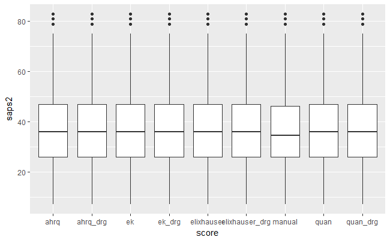

```r
ggplot(all_scores, aes(x = score, y = saps2)) +
    geom_boxplot()
```

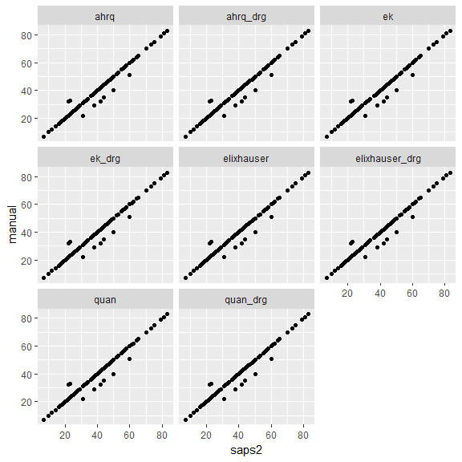

```r
df <- all_scores %>%
    spread(score, saps2) %>%
    gather(score, saps2, -pie.id, -manual)
ggplot(df, aes(x = saps2, y = manual)) +
    geom_point() +
    # geom_smooth() +
    facet_wrap(~ score)
```

- Comparison of scores

```r
t <- all_scores[, -1] %>%
    filter(score != "manual") %>%
    group_by(score) %>%
    do(tidy(t.test(.$saps2, man, paired = TRUE))) %>%
    ungroup() %>%
    mutate(bh.adjust = p.adjust(p.value, "BH")) %>%
    select(score:p.value, bh.adjust, everything())
knitr::kable(t, digits = 4)
```

| score | estimate | statistic | p.value | bh.adjust | parameter | conf.low | conf.high | method | alternative |
| --- | --- | --- | --- | --- | --- | --- | --- | --- | --- |
| ahrq | 0.18 | 1.3406 | 0.1816 | 0.1816 | 199 | -0.0848 | 0.4448 | Paired t-test | two.sided |
| ahrq_drg | 0.18 | 1.3406 | 0.1816 | 0.1816 | 199 | -0.0848 | 0.4448 | Paired t-test | two.sided |
| ek | 0.18 | 1.3406 | 0.1816 | 0.1816 | 199 | -0.0848 | 0.4448 | Paired t-test | two.sided |
| ek_drg | 0.18 | 1.3406 | 0.1816 | 0.1816 | 199 | -0.0848 | 0.4448 | Paired t-test | two.sided |
| elixhauser | 0.18 | 1.3406 | 0.1816 | 0.1816 | 199 | -0.0848 | 0.4448 | Paired t-test | two.sided |
| elixhauser_drg | 0.18 | 1.3406 | 0.1816 | 0.1816 | 199 | -0.0848 | 0.4448 | Paired t-test | two.sided |
| quan | 0.18 | 1.3406 | 0.1816 | 0.1816 | 199 | -0.0848 | 0.4448 | Paired t-test | two.sided |
| quan_drg | 0.18 | 1.3406 | 0.1816 | 0.1816 | 199 | -0.0848 | 0.4448 | Paired t-test | two.sided |

- Confidence interval was unable to be calculated for Wilcoxon analysis here

```r
mw <- all_scores[, -1] %>%
    filter(score != "manual") %>%
    group_by(score) %>%
    do(tidy(wilcox.test(.$saps2, man, paired = TRUE, exact = FALSE))) %>%
    ungroup() %>%
    mutate(bh.adjust = p.adjust(p.value, "BH")) %>%
    select(score:p.value, bh.adjust, everything())
knitr::kable(mw, digits = 4)
```

| score | statistic | p.value | bh.adjust | method | alternative |
| --- | --- | --- | --- | --- | --- |
| ahrq | 23 | 0.5182 | 0.5182 | Wilcoxon signed rank test with continuity correction | two.sided |
| ahrq_drg | 23 | 0.5182 | 0.5182 | Wilcoxon signed rank test with continuity correction | two.sided |
| ek | 23 | 0.5182 | 0.5182 | Wilcoxon signed rank test with continuity correction | two.sided |
| ek_drg | 23 | 0.5182 | 0.5182 | Wilcoxon signed rank test with continuity correction | two.sided |
| elixhauser | 23 | 0.5182 | 0.5182 | Wilcoxon signed rank test with continuity correction | two.sided |
| elixhauser_drg | 23 | 0.5182 | 0.5182 | Wilcoxon signed rank test with continuity correction | two.sided |
| quan | 23 | 0.5182 | 0.5182 | Wilcoxon signed rank test with continuity correction | two.sided |
| quan_drg | 23 | 0.5182 | 0.5182 | Wilcoxon signed rank test with continuity correction | two.sided |

#### Linear Regression Model

```r
lm <- df %>%
    group_by(score) %>%
    do(fit = lm(manual ~ saps2, data = .))
knitr::kable(glance(lm, fit), digits = 4)
```

| score | r.squared | adj.r.squared | sigma | statistic | p.value | df | logLik | AIC | BIC | deviance | df.residual |
| --- | --- | --- | --- | --- | --- | --- | --- | --- | --- | --- | --- |
| ahrq | 0.983 | 0.9829 | 1.8886 | 11449.91 | 0 | 2 | -409.9484 | 825.8968 | 835.7917 | 706.2182 | 198 |
| ahrq_drg | 0.983 | 0.9829 | 1.8886 | 11449.91 | 0 | 2 | -409.9484 | 825.8968 | 835.7917 | 706.2182 | 198 |
| ek | 0.983 | 0.9829 | 1.8886 | 11449.91 | 0 | 2 | -409.9484 | 825.8968 | 835.7917 | 706.2182 | 198 |
| ek_drg | 0.983 | 0.9829 | 1.8886 | 11449.91 | 0 | 2 | -409.9484 | 825.8968 | 835.7917 | 706.2182 | 198 |
| elixhauser | 0.983 | 0.9829 | 1.8886 | 11449.91 | 0 | 2 | -409.9484 | 825.8968 | 835.7917 | 706.2182 | 198 |
| elixhauser_drg | 0.983 | 0.9829 | 1.8886 | 11449.91 | 0 | 2 | -409.9484 | 825.8968 | 835.7917 | 706.2182 | 198 |
| quan | 0.983 | 0.9829 | 1.8886 | 11449.91 | 0 | 2 | -409.9484 | 825.8968 | 835.7917 | 706.2182 | 198 |
| quan_drg | 0.983 | 0.9829 | 1.8886 | 11449.91 | 0 | 2 | -409.9484 | 825.8968 | 835.7917 | 706.2182 | 198 |

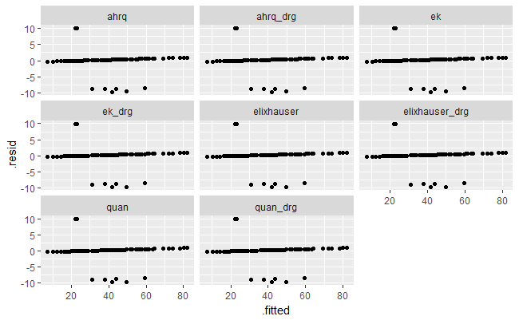

```r
augment(lm, fit) %>%
    ggplot(aes(x = .fitted, y = .resid)) +
    geom_point() +
    facet_wrap(~ score)
```

- Differences in score

```r
diff <- all_scores %>%
    spread(score, saps2) %>%
    mutate_at(vars(-pie.id, -manual), funs(abs(. - manual))) %>%
    gather(score, saps2, -pie.id, -manual) %>%
    select(-pie.id, -manual) %>%
    filter(saps2 > 0) %>%
    group_by(score) %>%
    summarize_all(funs(num_diff = length, mean, sd, median, IQR_low = quantile(., 0.25), IQR_high = quantile(., 0.75)))
knitr::kable(diff, caption = "Difference in SAPS II Scores")
```

| score | num_diff | mean | sd | median | IQR_low | IQR_high |
| --- | --- | --- | --- | --- | --- | --- |
| ahrq | 8 | 9.5 | 0.5345225 | 9.5 | 9 | 10 |
| ahrq_drg | 8 | 9.5 | 0.5345225 | 9.5 | 9 | 10 |
| ek | 8 | 9.5 | 0.5345225 | 9.5 | 9 | 10 |
| ek_drg | 8 | 9.5 | 0.5345225 | 9.5 | 9 | 10 |
| elixhauser | 8 | 9.5 | 0.5345225 | 9.5 | 9 | 10 |
| elixhauser_drg | 8 | 9.5 | 0.5345225 | 9.5 | 9 | 10 |
| quan | 8 | 9.5 | 0.5345225 | 9.5 | 9 | 10 |
| quan_drg | 8 | 9.5 | 0.5345225 | 9.5 | 9 | 10 |

## Secondary endpoints

### Predicted mortality

#### SAPS II

- Mean and median risk of mortality (as a percent) for each comorbidity set

```r
comorbid <- ls(pattern = "score_saps2_")
all_df <- map(comorbid, ~mutate(get(.x), score = .x)) %>%
    map(~select(.x, pie.id, score, saps2)) %>%
    map_df(~semi_join(.x, manual_patients, by = "pie.id")) %>%
    arrange(pie.id, score) %>%
    dmap_at("score", str_replace_all, pattern = "score_saps2_", replacement = "") %>%
    distinct(pie.id, score, .keep_all = TRUE) %>%
    mutate(logit = -7.763 + 0.0737 * saps2 + 0.9971 * log(saps2 + 1),
           mortality = exp(logit) / (1 + exp(logit))) %>%
    select(pie.id, score, mortality)
man <- filter(all_df, score == "manual")$mortality
result <- all_df %>%
    select(-pie.id) %>%
    group_by(score) %>%
    summarize_all(funs(mean, sd, median, IQR_low = quantile(., 0.25), IQR_high = quantile(., 0.75)))
knitr::kable(result, digits = 4)
```

| score | mean | sd | median | IQR_low | IQR_high |
| --- | --- | --- | --- | --- | --- |
| ahrq | 0.2513 | 0.2299 | 0.1810 | 0.0717 | 0.3919 |
| ahrq_drg | 0.2513 | 0.2299 | 0.1810 | 0.0717 | 0.3919 |
| ek | 0.2513 | 0.2299 | 0.1810 | 0.0717 | 0.3919 |
| ek_drg | 0.2513 | 0.2299 | 0.1810 | 0.0717 | 0.3919 |
| elixhauser | 0.2513 | 0.2299 | 0.1810 | 0.0717 | 0.3919 |
| elixhauser_drg | 0.2513 | 0.2299 | 0.1810 | 0.0717 | 0.3919 |
| manual | 0.2476 | 0.2280 | 0.1597 | 0.0717 | 0.3752 |
| quan | 0.2513 | 0.2299 | 0.1810 | 0.0717 | 0.3919 |
| quan_drg | 0.2513 | 0.2299 | 0.1810 | 0.0717 | 0.3919 |

```r
t <- all_df[, -1] %>%
    filter(score != "manual") %>%
    group_by(score) %>%
    do(tidy(t.test(.$mortality, man, paired = TRUE))) %>%
    ungroup() %>%
    mutate(bh.adjust = p.adjust(p.value, "BH")) %>%
    select(score:p.value, bh.adjust, everything())
knitr::kable(t, digits = 4)
```

| score | estimate | statistic | p.value | bh.adjust | parameter | conf.low | conf.high | method | alternative |
| --- | --- | --- | --- | --- | --- | --- | --- | --- | --- |
| ahrq | 0.0037 | 1.8305 | 0.0687 | 0.0687 | 199 | -0.0003 | 0.0077 | Paired t-test | two.sided |
| ahrq_drg | 0.0037 | 1.8305 | 0.0687 | 0.0687 | 199 | -0.0003 | 0.0077 | Paired t-test | two.sided |
| ek | 0.0037 | 1.8305 | 0.0687 | 0.0687 | 199 | -0.0003 | 0.0077 | Paired t-test | two.sided |
| ek_drg | 0.0037 | 1.8305 | 0.0687 | 0.0687 | 199 | -0.0003 | 0.0077 | Paired t-test | two.sided |
| elixhauser | 0.0037 | 1.8305 | 0.0687 | 0.0687 | 199 | -0.0003 | 0.0077 | Paired t-test | two.sided |
| elixhauser_drg | 0.0037 | 1.8305 | 0.0687 | 0.0687 | 199 | -0.0003 | 0.0077 | Paired t-test | two.sided |
| quan | 0.0037 | 1.8305 | 0.0687 | 0.0687 | 199 | -0.0003 | 0.0077 | Paired t-test | two.sided |
| quan_drg | 0.0037 | 1.8305 | 0.0687 | 0.0687 | 199 | -0.0003 | 0.0077 | Paired t-test | two.sided |

```r
mw <- all_df[, -1] %>%
    filter(score != "manual") %>%
    group_by(score) %>%
    do(tidy(wilcox.test(.$mortality, man, paired = TRUE, conf.int = TRUE, exact = FALSE))) %>%
    ungroup() %>%
    mutate(bh.adjust = p.adjust(p.value, "BH")) %>%
    select(score:p.value, bh.adjust, everything())
knitr::kable(mw, digits = 4)
```

| score | estimate | statistic | p.value | bh.adjust | conf.low | conf.high | method | alternative |
| --- | --- | --- | --- | --- | --- | --- | --- | --- |
| ahrq | 0.1146 | 31 | 0.0801 | 0.0801 | -0.0088 | 0.1865 | Wilcoxon signed rank test with continuity correction | two.sided |
| ahrq_drg | 0.1146 | 31 | 0.0801 | 0.0801 | -0.0088 | 0.1865 | Wilcoxon signed rank test with continuity correction | two.sided |
| ek | 0.1146 | 31 | 0.0801 | 0.0801 | -0.0088 | 0.1865 | Wilcoxon signed rank test with continuity correction | two.sided |
| ek_drg | 0.1146 | 31 | 0.0801 | 0.0801 | -0.0088 | 0.1865 | Wilcoxon signed rank test with continuity correction | two.sided |
| elixhauser | 0.1146 | 31 | 0.0801 | 0.0801 | -0.0088 | 0.1865 | Wilcoxon signed rank test with continuity correction | two.sided |
| elixhauser_drg | 0.1146 | 31 | 0.0801 | 0.0801 | -0.0088 | 0.1865 | Wilcoxon signed rank test with continuity correction | two.sided |
| quan | 0.1146 | 31 | 0.0801 | 0.0801 | -0.0088 | 0.1865 | Wilcoxon signed rank test with continuity correction | two.sided |
| quan_drg | 0.1146 | 31 | 0.0801 | 0.0801 | -0.0088 | 0.1865 | Wilcoxon signed rank test with continuity correction | two.sided |

- Difference in risk of mortality
  - Mean and median calculated using only those patients whose predicted mortality score was different from manual

```r
diff <- all_df %>%
    spread(score, mortality) %>%
    mutate_at(vars(-pie.id, -manual), funs(abs(. - manual))) %>%
    gather(score, saps2, -pie.id, -manual) %>%
    select(-pie.id, -manual) %>%
    filter(saps2 > 0) %>%
    group_by(score) %>%
    summarize_all(funs(num_diff = length, mean, sd, median, IQR_low = quantile(., 0.25), IQR_high = quantile(., 0.75)))
knitr::kable(diff, caption = "Difference in Predicted Mortality using SAPS II")
```

| score | num_diff | mean | sd | median | IQR_low | IQR_high |
| --- | --- | --- | --- | --- | --- | --- |
| ahrq | 8 | 0.1353385 | 0.0544702 | 0.1366591 | 0.0862261 | 0.1691449 |
| ahrq_drg | 8 | 0.1353385 | 0.0544702 | 0.1366591 | 0.0862261 | 0.1691449 |
| ek | 8 | 0.1353385 | 0.0544702 | 0.1366591 | 0.0862261 | 0.1691449 |
| ek_drg | 8 | 0.1353385 | 0.0544702 | 0.1366591 | 0.0862261 | 0.1691449 |
| elixhauser | 8 | 0.1353385 | 0.0544702 | 0.1366591 | 0.0862261 | 0.1691449 |
| elixhauser_drg | 8 | 0.1353385 | 0.0544702 | 0.1366591 | 0.0862261 | 0.1691449 |
| quan | 8 | 0.1353385 | 0.0544702 | 0.1366591 | 0.0862261 | 0.1691449 |
| quan_drg | 8 | 0.1353385 | 0.0544702 | 0.1366591 | 0.0862261 | 0.1691449 |

### Number of comorbidities

#### APACHE II

- Mean represents the average number of comorbidities per patient

```r
comorbid <- ls(pattern = "data_apache2_")
all_df <- map(comorbid, ~mutate(get(.x), score = .x)) %>%
    map(~distinct(.x, pie.id, score, liver, cardiovasc, respiratory, renal, immunocomp, comorbidity)) %>%
    map_df(~semi_join(.x, manual_patients, by = "pie.id")) %>%
    arrange(pie.id, score) %>%
    dmap_at("score", str_replace_all, pattern = "data_apache2_", replacement = "") %>%
    mutate_if(is.logical, as.numeric) %>%
    by_row(function(x) sum(x[, 3:7], na.rm = TRUE), .collate = "rows", .to = "num_comorbid") %>%
    select(pie.id, score, num_comorbid)
man <- filter(all_df, score == "manual")$num_comorbid
result <- all_df %>%
    select(-pie.id) %>%
    group_by(score) %>%
    summarize_all(funs(mean, sd, median, IQR_low = quantile(., 0.25), IQR_high = quantile(., 0.75)))
knitr::kable(result)
```

| score | mean | sd | median | IQR_low | IQR_high |
| --- | --- | --- | --- | --- | --- |
| ahrq | 0.760 | 0.7314885 | 1 | 0 | 1 |
| ahrq_drg | 0.595 | 0.6732319 | 0 | 0 | 1 |
| ek | 0.690 | 0.7186671 | 1 | 0 | 1 |
| ek_drg | 0.530 | 0.6412143 | 0 | 0 | 1 |
| elixhauser | 0.745 | 0.7366739 | 1 | 0 | 1 |
| elixhauser_drg | 0.575 | 0.6607252 | 0 | 0 | 1 |
| manual | 0.605 | 0.7222070 | 0 | 0 | 1 |
| quan | 0.750 | 0.7417892 | 1 | 0 | 1 |
| quan_drg | 0.585 | 0.6670832 | 0 | 0 | 1 |

```r
t <- all_df[, -1] %>%
    filter(score != "manual") %>%
    group_by(score) %>%
    do(tidy(t.test(.$num_comorbid, man, paired = TRUE))) %>%
    ungroup() %>%
    mutate(bh.adjust = p.adjust(p.value, "BH")) %>%
    select(score:p.value, bh.adjust, everything())
knitr::kable(t, digits = 4)
```

| score | estimate | statistic | p.value | bh.adjust | parameter | conf.low | conf.high | method | alternative |
| --- | --- | --- | --- | --- | --- | --- | --- | --- | --- |
| ahrq | 0.155 | 2.5932 | 0.0102 | 0.0513 | 199 | 0.0371 | 0.2729 | Paired t-test | two.sided |
| ahrq_drg | -0.010 | -0.1737 | 0.8623 | 0.8623 | 199 | -0.1236 | 0.1036 | Paired t-test | two.sided |
| ek | 0.085 | 1.4253 | 0.1556 | 0.2997 | 199 | -0.0326 | 0.2026 | Paired t-test | two.sided |
| ek_drg | -0.075 | -1.3232 | 0.1873 | 0.2997 | 199 | -0.1868 | 0.0368 | Paired t-test | two.sided |
| elixhauser | 0.140 | 2.3598 | 0.0193 | 0.0513 | 199 | 0.0230 | 0.2570 | Paired t-test | two.sided |
| elixhauser_drg | -0.030 | -0.5336 | 0.5942 | 0.7923 | 199 | -0.1409 | 0.0809 | Paired t-test | two.sided |
| quan | 0.145 | 2.4379 | 0.0157 | 0.0513 | 199 | 0.0277 | 0.2623 | Paired t-test | two.sided |
| quan_drg | -0.020 | -0.3528 | 0.7246 | 0.8281 | 199 | -0.1318 | 0.0918 | Paired t-test | two.sided |

```r
mw <- all_df[, -1] %>%
    filter(score != "manual") %>%
    group_by(score) %>%
    do(tidy(wilcox.test(.$num_comorbid, man, paired = TRUE, conf.int = TRUE, exact = FALSE))) %>%
    ungroup() %>%
    mutate(bh.adjust = p.adjust(p.value, "BH")) %>%
    select(score:p.value, bh.adjust, everything())
knitr::kable(mw, digits = 4)
```

| score | estimate | statistic | p.value | bh.adjust | conf.low | conf.high | method | alternative |
| --- | --- | --- | --- | --- | --- | --- | --- | --- |
| ahrq | 0 | 3059.5 | 0.0077 | 0.0521 | 0.0001 | 1.0000 | Wilcoxon signed rank test with continuity correction | two.sided |
| ahrq_drg | 0 | 1933.0 | 0.9118 | 0.9118 | 0.0000 | 0.0000 | Wilcoxon signed rank test with continuity correction | two.sided |
| ek | 0 | 2553.5 | 0.1276 | 0.2552 | 0.0000 | 0.5000 | Wilcoxon signed rank test with continuity correction | two.sided |
| ek_drg | 0 | 1560.5 | 0.2053 | 0.3285 | -0.5000 | 0.0000 | Wilcoxon signed rank test with continuity correction | two.sided |
| elixhauser | 0 | 2752.5 | 0.0196 | 0.0521 | 0.0000 | 0.5000 | Wilcoxon signed rank test with continuity correction | two.sided |
| elixhauser_drg | 0 | 1672.0 | 0.5878 | 0.7837 | 0.0000 | 0.0001 | Wilcoxon signed rank test with continuity correction | two.sided |
| quan | 0 | 2826.0 | 0.0161 | 0.0521 | 0.0000 | 0.5000 | Wilcoxon signed rank test with continuity correction | two.sided |
| quan_drg | 0 | 1791.0 | 0.7129 | 0.8148 | 0.0000 | 0.0000 | Wilcoxon signed rank test with continuity correction | two.sided |

### Proportion with differing comorbidity

#### APACHE II

- Proportion of patients where a comorbidity was identified by ICD or by manual, but not both

```r
comorbid <- ls(pattern = "data_apache2_")
all_df <- map(comorbid, ~mutate(get(.x), score = .x)) %>%
    map(~distinct(.x, pie.id, score, comorbidity)) %>%
    map_df(~semi_join(.x, manual_patients, by = "pie.id")) %>%
    arrange(pie.id, score) %>%
    dmap_at("score", str_replace_all, pattern = "data_apache2_", replacement = "") %>%
    spread(score, comorbidity) %>%
    mutate_at(vars(-pie.id, -manual), funs(. != manual)) %>%
    mutate_if(is.logical, as.numeric) %>%
    ungroup() %>%
    gather(score, comorbidity, -pie.id, -manual) %>%
    select(-pie.id, -manual) %>%
    group_by(score) %>%
    summarize_all(funs(num_diff = sum(. > 0), proportion = mean))
knitr::kable(all_df)
```

| score | num_diff | proportion |
| --- | --- | --- |
| ahrq | 72 | 0.360 |
| ahrq_drg | 68 | 0.340 |
| ek | 71 | 0.355 |
| ek_drg | 68 | 0.340 |
| elixhauser | 70 | 0.350 |
| elixhauser_drg | 66 | 0.330 |
| quan | 70 | 0.350 |
| quan_drg | 67 | 0.335 |

#### APACHE III

- Proportion of patients where the primary comorbidity identified by ICD varied from primary comorbidity identified by manual

```r
comorbid <- ls(pattern = "data_apache3_")
all_df <- map(comorbid, ~mutate(get(.x), score = .x)) %>%
    map(~distinct(.x, pie.id, score, comorbidity)) %>%
    map_df(~semi_join(.x, manual_patients, by = "pie.id")) %>%
    arrange(pie.id, score) %>%
    dmap_at("score", str_replace_all, pattern = "data_apache3_", replacement = "") %>%
    spread(score, comorbidity, fill = "") %>%
    dmap(str_replace_all, pattern = "none", replacement = "") %>%
    mutate_at(vars(-pie.id, -manual), funs(. != manual)) %>%
    mutate_if(is.logical, as.numeric) %>%
    gather(score, comorbidity, -pie.id, -manual) %>%
    select(-pie.id, -manual) %>%
    group_by(score) %>%
    summarize_all(funs(num_diff = sum(. > 0), proportion = mean))
knitr::kable(all_df)
```

| score | num_diff | proportion |
| --- | --- | --- |
| ahrq | 32 | 0.160 |
| ahrq_drg | 31 | 0.155 |
| ek | 32 | 0.160 |
| ek_drg | 31 | 0.155 |
| elixhauser | 32 | 0.160 |
| elixhauser_drg | 31 | 0.155 |
| quan | 32 | 0.160 |
| quan_drg | 31 | 0.155 |

#### SAPS II

- Proportion of patients where the primary comorbidity identified by ICD varied from primary comorbidity identified by manual

```r
comorbid <- ls(pattern = "data_saps2_")
all_df <- map(comorbid, ~mutate(get(.x), score = .x)) %>%
    map(~distinct(.x, pie.id, score, comorbidity)) %>%
    map_df(~semi_join(.x, manual_patients, by = "pie.id")) %>%
    arrange(pie.id, score) %>%
    dmap_at("score", str_replace_all, pattern = "data_saps2_", replacement = "") %>%
    spread(score, comorbidity, fill = "") %>%
    dmap(str_replace_all, pattern = "none", replacement = "") %>%
    mutate_at(vars(-pie.id, -manual), funs(. != manual)) %>%
    mutate_if(is.logical, as.numeric) %>%
    gather(score, comorbidity, -pie.id, -manual) %>%
    select(-pie.id, -manual) %>%
    group_by(score) %>%
    summarize_all(funs(num_diff = sum(. > 0), proportion = mean))
knitr::kable(all_df)
```

| score | num_diff | proportion |
| --- | --- | --- |
| ahrq | 8 | 0.04 |
| ahrq_drg | 8 | 0.04 |
| ek | 8 | 0.04 |
| ek_drg | 8 | 0.04 |
| elixhauser | 8 | 0.04 |
| elixhauser_drg | 8 | 0.04 |
| quan | 8 | 0.04 |
| quan_drg | 8 | 0.04 |